# 2019’s Best NFL Rushers Based on Advanced Statistics

Alec Engel

8/8/2021

**Expected Points (EP)**  
Expected Points is a statistical measurement unit of an NFL team’s expected points for or against when in possession the ball. This measurement accounts for numerous factors within a game such as location on the field, what down it is, how far the offensive team needs to travel for a first down, the time remaining in a game and factoring in home-field advantage. Expected Points is represented by adding each expected points added/subtracted per play. It’s significance in a game is to provide a number for the expected amount of points that will be scored next.

EP=(sum of probabilities)(next point prediction amount)

**Expected Points Added (EPA)**  
Expected Points Added is the measurement that adjusts a team’s expected points from pre to post play. This can be a positive add such as a first down that would increase overall expected points, or a negative play such as a fumble that would decrease overall expected points. EPA amounts are accumulated by individual play performance as well as specific player actions such as a passer, receiver or ball carrier. EPA is calculated by adding together the probability and value of success with the probability and value of failure.

EPA=P(Success)(Value of Success)+P(Failure)(Value of Failure)

**Highest Total 2019 EPA for Rushers**  
The highest total EPA for rushers in the 2019 season are represented below. Rushers are defined as any skilled position player that runs with the ball from behind the line of scrimmage. We can see that Lamar Jackson has more doubled the second best “rusher” (Patrick Mahomes) with his 2019 league MVP performance. Interestingly enough, we also see this statistic dominated not by running backs, but by quarterbacks. The top 20 has 13 qbs, 6 rbs and 1 wr. We also see that the highest EPA running back and wide receiver both came from the San Francisco 49ers rushing attack in Raheem Mostert and Deebo Samuel respectively so we can most likely crown the 49ers as having one of if not the best rushing schemes in the 2019 NFL season.

| Rusher | SeasonEPA |
| --- | --- |
| L.Jackson | 72.7 |
| P.Mahomes | 36.1 |
| D.Watson | 31.4 |
| R.Mostert | 29.3 |
| J.Allen | 21.5 |
| R.Tannehill | 21.4 |
| D.Jones | 18.2 |
| D.Samuel | 17.5 |
| M.Ryan | 17.5 |
| D.Cook | 16.1 |

[output cut: 40 more lines]

| Game | Rusher | GameEPA |
| --- | --- | --- |
| 2019_20_GB_SF | R.Mostert | 14.1 |
| 2019_07_BAL_SEA | L.Jackson | 11.2 |
| 2019_04_JAX_DEN | L.Fournette | 10 |
| 2019_17_TEN_HOU | D.Henry | 9.6 |
| 2019_17_LAC_KC | Dam.Williams | 9.5 |
| 2019_03_BAL_KC | M.Ingram | 9.1 |
| 2019_13_WAS_CAR | D.Guice | 9.1 |
| 2019_01_IND_LAC | M.Mack | 8.8 |
| 2019_03_NYG_TB | D.Jones | 8.3 |
| 2019_06_CIN_BAL | L.Jackson | 8.2 |

[output cut: 2027 more lines]

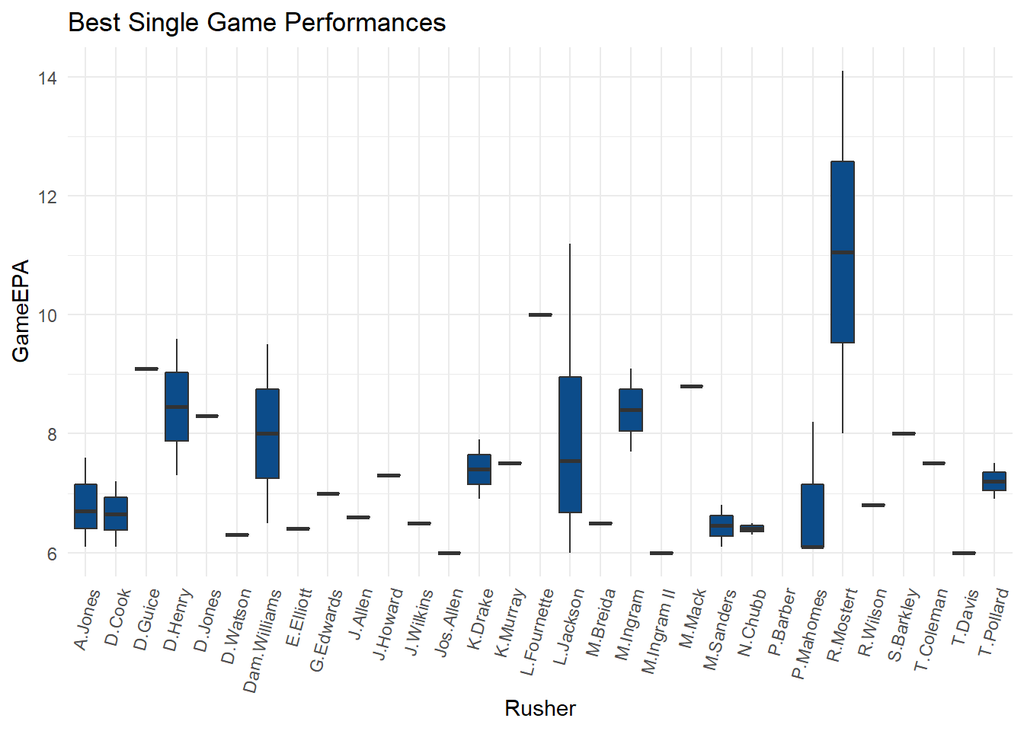

**Lowest Totals of 2019 EPA Among Rushers**  
Who had the worst rushing year in terms of EPA for 2019? We’ve previously highlighted top rushing performances in 2019 but will now take a look at some of the poorest performers. Surprisingly, there are several bell cow (pun intended) running backs at the top of this list.

| Rusher | SeasonEPA |
| --- | --- |
| L.Bell | -39.4 |
| D.Montgomery | -30.8 |
| D.Freeman | -29 |
| F.Gore | -26.5 |
| T.Gurley | -25.9 |
| S.Michel | -22.1 |
| D.Johnson | -22 |
| J.Conner | -20.1 |
| P.Laird | -20 |
| K.Johnson | -19.9 |

[output cut: 40 more lines]

**Worst Single Game Rushing Performances of 2019**  
Which NFL game from 2019 experienced the worst independent rushing performances? The lowest EPA performance for a game as shown below was Chris Carson against the Saints followed by Kerryan Johnson against the Chiefs. We can also see a trend here with names on these terrible EPA rushing games likely negatively effecting each rusher’s season EPA totals.

| Game | Rusher | GameEPA |
| --- | --- | --- |
| 2019_03_NO_SEA | C.Carson | -16.9 |
| 2019_04_KC_DET | K.Johnson | -13.2 |
| 2019_14_SF_NO | A.Kamara | -11 |
| 2019_03_NYJ_NE | L.Bell | -10.4 |
| 2019_10_KC_TEN | Dam.Williams | -9.9 |
| 2019_17_ARI_LA | K.Murray | -9.9 |
| 2019_10_LA_PIT | M.Rudolph | -8.8 |
| 2019_11_CHI_LA | T.Gurley | -8.5 |
| 2019_01_ATL_MIN | D.Freeman | -8.3 |
| 2019_07_LAC_TEN | M.Gordon | -8.1 |

[output cut: 2027 more lines]

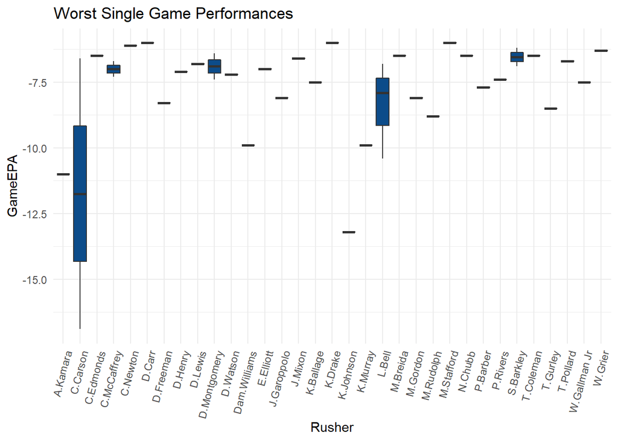